# 2016 Presidential Contributions

Zohaib Anwar

August 12, 2017

# Introduction

In this study I look at data from the 2016 Presidential election by candidate, total contributions, location of, and number of contributors. For each of these variables I try to parse the data and create some visualizations that sum up the data well. I end up creating a statististical summary with bar and line plots, overview of the data by plotting, on a world map, some of the aforementioned varibles, and a general box plot to differentiate between gender and party in the election.

```r
setwd("C:/USers/Zohaib/Desktop/Lectures/Udacity/R")
#Setting the correct working directory.
Contributions<-read.csv("ContributionsEdited.csv",header = TRUE,na.strings="",
                        encoding="UTF-8") #Reading in the data.
```

```r
library(plyr) #Setting up the libraries for the following code.
library(ggplot2)
library(gridExtra)
library(maps)
library(ggmap)
library(devtools)
library(dplyr)
```

```r
for (i in c("cand_nm","election_tp")){print(sort(table(Contributions[i]),
                                                 decreasing=TRUE))}
```

```
##
##   Clinton, Hillary Rodham          Sanders, Bernard
##                   3506081                   2063097
##          Trump, Donald J. Cruz, Rafael Edward 'Ted'
##                    782711                    557581
##       Carson, Benjamin S.              Rubio, Marco
##                    248227                    104814
##                Paul, Rand                 Bush, Jeb
##                     32485                     29459
##            Fiorina, Carly           Kasich, John R.
##                     27793                     25498
##             Johnson, Gary               Stein, Jill
##                     13429                     11020
##             Walker, Scott            Huckabee, Mike
##                      7338                      6460
##  Christie, Christopher J.   O'Malley, Martin Joseph
##                      5998                      5317
##        Graham, Lindsey O.            McMullin, Evan
##                      4397                      2540
##      Santorum, Richard J.          Lessig, Lawrence
##                      1723                      1339
##    Perry, James R. (Rick)     Webb, James Henry Jr.
##                       908                       800
##             Jindal, Bobby         Pataki, George E.
##                       765                       344
##      Gilmore, James S III
##                        88
##
##   P2016   G2016   O2016   P2020   P2012   P2018   G2015   P2015   G2106
## 4789297 2634940    1891      76       3       3       2       2       1
##   P2019
##       1
```

```r
# Gives table counts for each candidate and election.
Contributions$names<-lapply(as.character(Contributions$cand_nm),
                            function(x) strsplit(x,",")[[1]][1])
Contributions$names<-factor(Contributions$names,levels=sort(
  as.vector(as.character(unique((Contributions$names))))))
#Creates and easier to use name variable, with just last names.
```

As expected, the most number of the contributions are going to the popular choice, Clinton, the fundraising upset Sanders, and election winner Trump. For the rest of the individuals, one can get a sense of how the election turned out just by looking at the differing number of contributions.

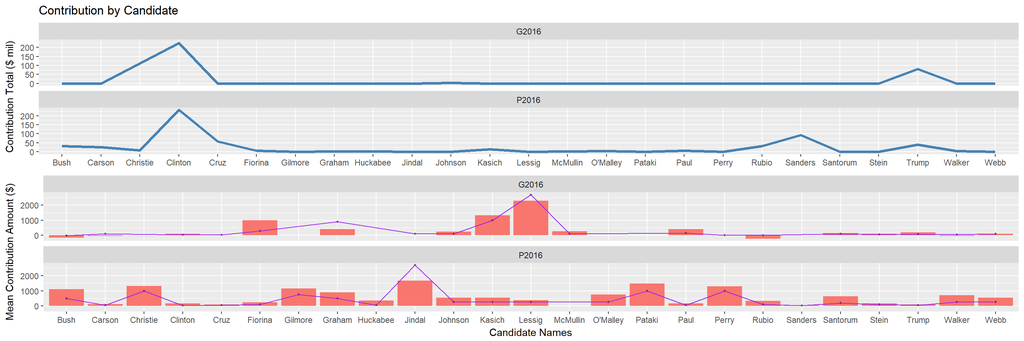

```r
plotCont<-subset(Contributions,election_tp=="P2016"|election_tp=="G2016") #Creates data set to focus on 2016 election.
p1<-ggplot(aes(x=names,y=contb_receipt_amt,group=1),
       data=plotCont)+
  geom_bar(aes(fill='red'),stat="summary",fun.y=mean)+ #bar plot for mean of contbributions by candidate
  facet_wrap(~election_tp,nrow = 2)+                   #split into the primary and general elections.
  geom_point(alpha=.5,size=.75,stat="summary",fun.y=median)+
  geom_line(color='purple',stat="summary",fun.y=median)+ #line plot for median contributions.
  labs(x="Candidate Names",y="Mean Contribution Amount ($)")+
  theme(plot.title = element_text(size=22))+
  guides(fill=FALSE)
p2<-ggplot(aes(x=names,y=contb_receipt_amt/1000000,group=1),
           data=plotCont)+
  ylab("Contribution Total ($ mil)")+          #line plot for sum of contributions by candidate split by primary and
  ggtitle("Contribution by Candidate")+        #general elections.
  geom_line(size=1.25,color='steelblue',stat="summary",fun.y=sum)+
  theme(axis.title.x=element_blank())+
  facet_wrap(~election_tp,nrow=2)+
  guides(fill=FALSE)
grid.arrange(p2,p1)
```

From this one can notice something odd about the mean contributions as some of the individuals you would expect to have high mean and/or median contributions do not! Clinton, Sanders, and Trump all have low amounts in comparison.The three, on the other hand, do obviously have the highest total contributions, but one should find it very odd that some of the prominent candidates had low statistics, while someone like Jindal had or Lessig both had very high amounts. Then there are the negative means (most likely due to reimbursements), and contributions in the general election for people that were not even in the race such as Lessig who has a high mean amount of contributions then. Yet, when one looks at the count for Lessign he only has 1339 contributions so these numbers are a little less concerning.

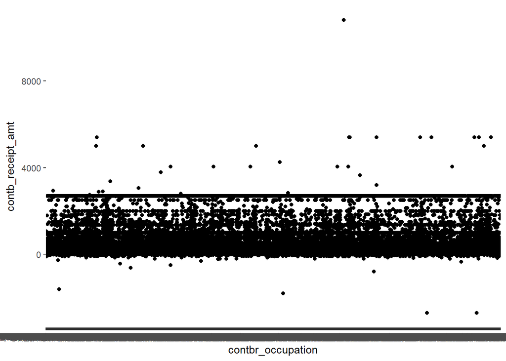

```r
ggplot(aes(x=contbr_occupation,y=contb_receipt_amt),
       data=plotCont)+
  geom_point(stat="summary",fun.y=mean)
```

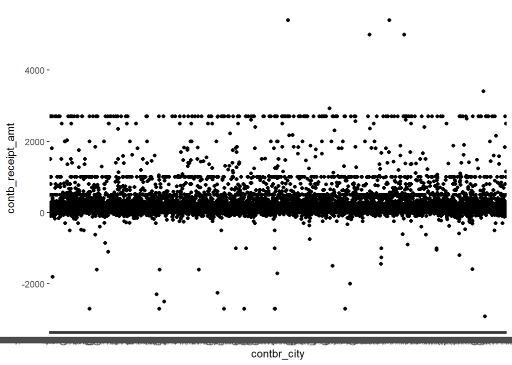

```r
ggplot(aes(x=contbr_city,y=contb_receipt_amt), #Two plots trying to create scatter plots by city and occupation versus
       data=plotCont)+                         #receipt amounts, but this obviously does not seem like the best plots.
  geom_point(stat="summary",fun.y=mean)
```

In an attempt to determine some information from occupation of the contributors and cities, I plot these variables against the mean contribution amount for them but these plots do not really say anything, and it is near impossible to do anything worth-while with them.

```r
Contributions$Gender<-NA
Contributions$Party<-NA
Males=c("Rubio","Santorum","Perry","Carson","Cruz","Paul","Sanders","Huckabee",
        "Pataki","O'Malley","Graham","Bush","Trump","Jindal","Christie",
        "Walker","Webb","Kasich","Gilmore","Lessig","Johnson","McMullin")
Females=c("Clinton","Fiorina","Stein")
Republicans=c("Rubio","Santorum","Perry","Carson","Cruz","Fiorina","Paul","Huckabee",
              "Pataki","O'Malley","Graham","Bush","Trump","Jindal","Christie",
              "Walker","Kasich","Gilmore")
Democrats=c("Clinton","Sanders","Webb","Lessig")
Others=c("Stein","Johnson","McMullin")
#Creating Gender and Party variables based off of a list of the names that
#fall in each category.
for (i in Contributions$names){
  if (i %in% Males) {
    Contributions$Gender="M"
  }
  else if (i %in% Females) {
    Contributions$Gender="F"
  }
  else {
    Contributions$Gender=NA}}
for (i in Contributions$names){
  if (i %in% Republicans){
    Contributions$Party="R"
  }
  else if (i %in% Democrats) {
    Contributions$Party="D"
  }
  else if (i %in% Others){
    Contributions$Party="O"
  }
  else {
    Contributions$Party=NA
  }}
```

```r
for (i in unique(Contributions$gender)){
  print(c(i,quantile(x=Contributions[
    Contributions$gender==i,]$contb_receipt_amt,probs = .85)))
  } #calculates 85th percentile for contributions by gender.
```

```
##         85%
##   "M" "100"
##         85%
##   "F" "100"
```

```r
for (i in unique(Contributions$party)){
  print(c(i,quantile(Contributions[
    Contributions$party==i,]$contb_receipt_amt,probs = .85)))
} #calculates 85th percentile for contributions by party.
```

```
##         85%
##   "R" "250"
##         85%
##   "D" "100"
##         85%
##   "O" "500"
```

This data is just to get a sense of the data for the following plots, which need scaling manipulations.

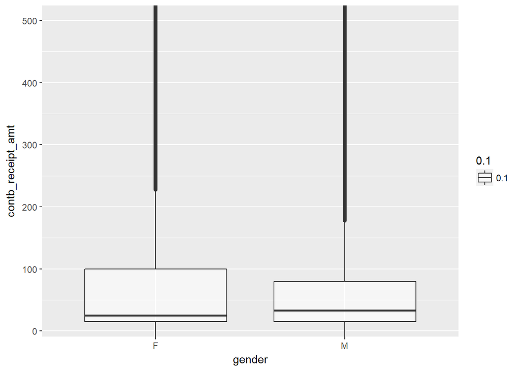

```r
ggplot(aes(x=gender,y=contb_receipt_amt),data=plotCont)+
  geom_boxplot(aes(alpha=.1))+
  coord_cartesian(ylim=c(quantile(Contributions[
    Contributions$gender=="F",]$contb_receipt_amt,probs = .25),
                         quantile(Contributions[
                           Contributions$gender=="F",]$contb_receipt_amt,
                           probs = .95)))+
  guides(fill=FALSE)
```

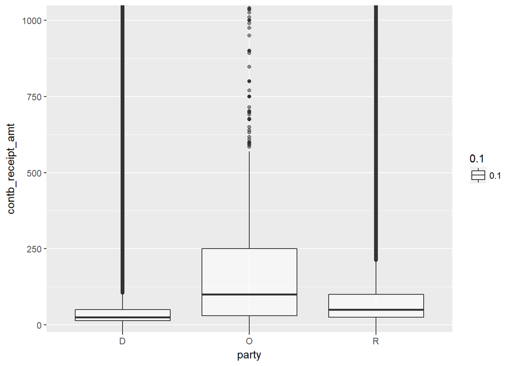

```r
ggplot(aes(x=party,y=contb_receipt_amt),data=plotCont)+
  geom_boxplot(aes(alpha=.1))+
  coord_cartesian(ylim=c(quantile(
    Contributions[Contributions$party=="R",]$contb_receipt_amt,probs=.25),
                         quantile(
                           Contributions[
                             Contributions$party=="R",]$contb_receipt_amt,
                           probs=.95)))+
  guides(fill=FALSE) #plotting boxplots for both contributions by gender and party with the 25th and 95th percentiles
```

```r
                     #used to give a better picture of the plots.
```

In order to view differences across party and gender I create boxplots for them, one of the best ways to visually check. Here differences between gender and party are shown in terms of contributions, although, oddly the “Other” party types have a higher median amount of contributions when compared to Republicans and Democrats, although both of the latter have very high outliers throughout the plots. This is probably due to the lower count of contributions that was donated to the Other parties.

```r
namelist<-unique(Contributions$names)
for (i in namelist){
  assign(i,subset(plotCont,names==i)%>% #Assigns each candidate name to a dataframe of cities and counts.
    group_by(names,contbr_city,contbr_st) %>% #Grouping by city and state to get counts for each for each candidate.
    summarize(n=n()) %>%
    ungroup() %>%
    ungroup())
  i<-arrange(get(i),desc(n))
  print(head(i,n = 10)) #printing tables of the top ten cities in terms of count of contributions from there.
}
```

```
## # A tibble: 10 x 4
##     names contbr_city contbr_st     n
##    <fctr>      <fctr>    <fctr> <int>
##  1  Rubio       MIAMI        FL  2258
##  2  Rubio    NEW YORK        NY  1538
##  3  Rubio     HOUSTON        TX  1349
##  4  Rubio      NAPLES        FL  1258
##  5  Rubio      DALLAS        TX  1214
##  6  Rubio LOS ANGELES        CA   874
##  7  Rubio  WASHINGTON        DC   858
##  8  Rubio     ATLANTA        GA   679
##  9  Rubio     CHICAGO        IL   645
## 10  Rubio  BOCA RATON        FL   608
## # A tibble: 10 x 4
##       names       contbr_city contbr_st     n
```

[output cut: 310 more lines]

I feel this is an extremely informative presentation of the data, as one can determine the top cities where each candidate received funds from. This information is highly valuable.Looking at just Clinton, she got the most from New York, D.C., and Los Angeles, Trump from HOuston, Dallas and Nevada (southern states) and Sanders from New York, Seattle, and Los Angeles.

```r
for (i in namelist){a<-get(i)
                 a$location<-paste(as.character(a$city),as.character(
                   a$contbr_city))
                 a$lat<- sapply(a$location,                          #Getting the longitude and latitude for each
                                        function(x)                  #candidate.
                                          if (!is.na(x)){
                                            geocode(x,source ="dsk",
                                                    messaging = FALSE)$lat}
                                        else {NA})
                 a$lon<- sapply(a$location,
                                       function(x)
                                         if (!is.na(x)){
                                           geocode(x,source ="dsk",
                                                   messaging = FALSE)$lon}
                                       else {NA})
                 assign(i,a) #Assigning the new information to the candidate dataframes.
                 remove(a)
}
```

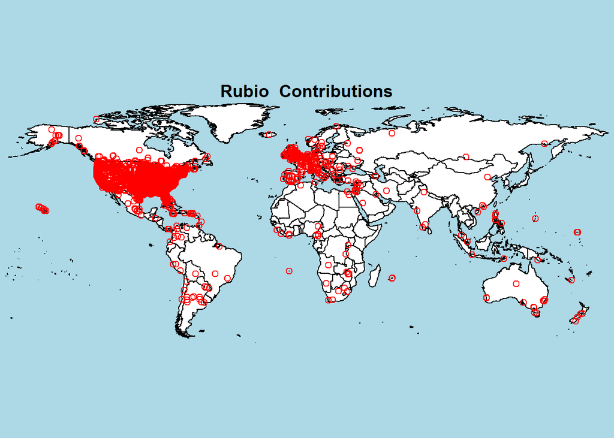

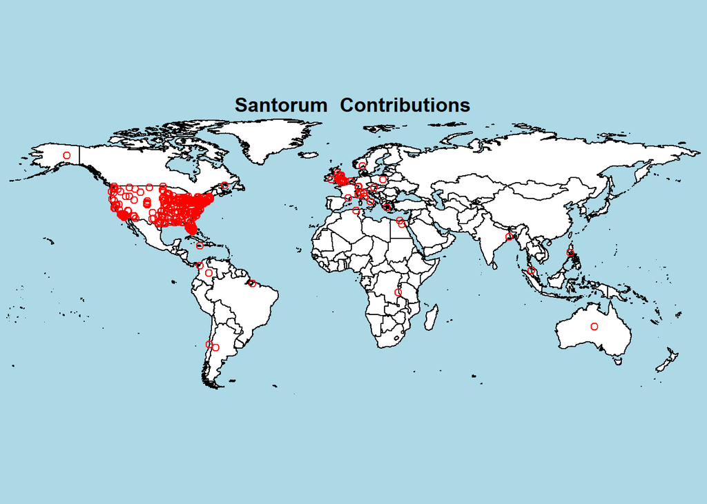

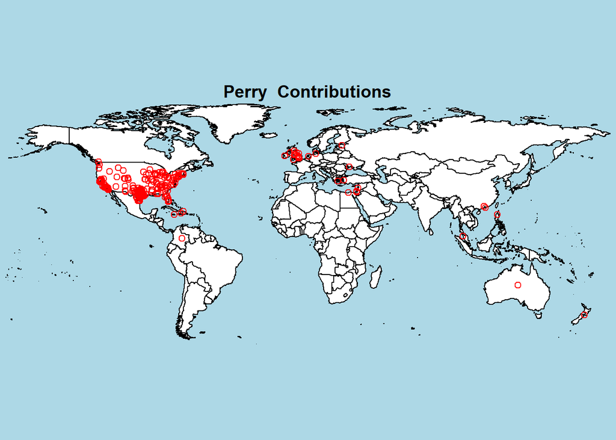

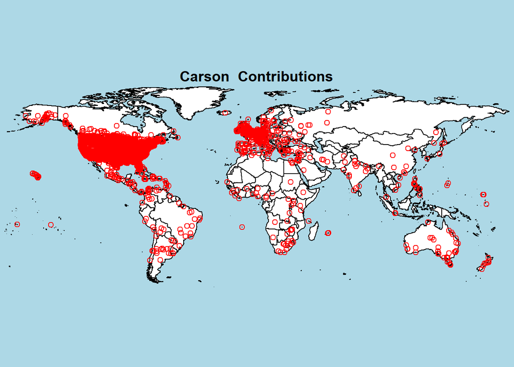

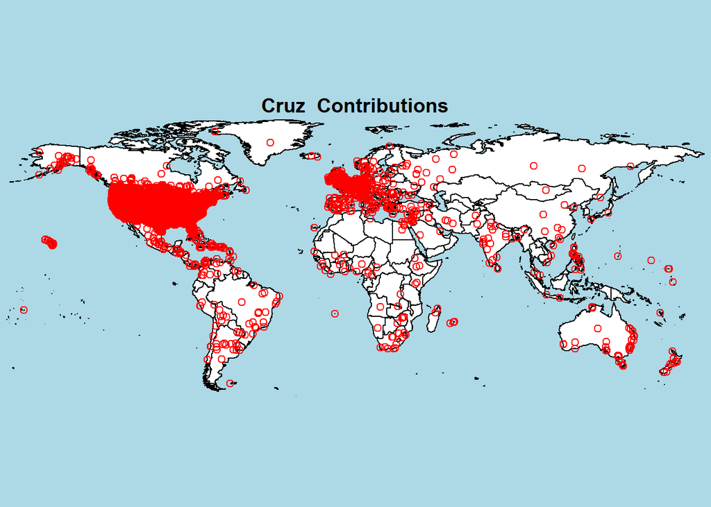

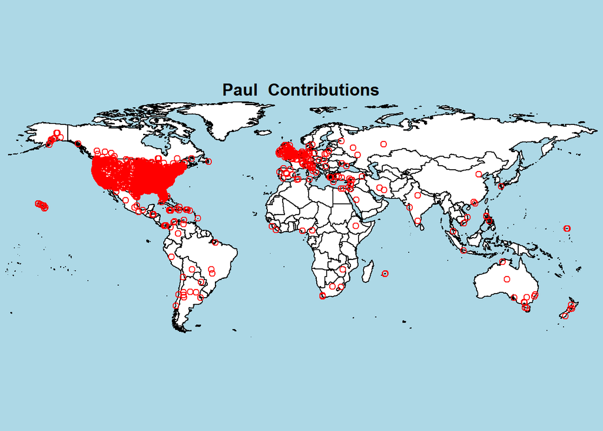

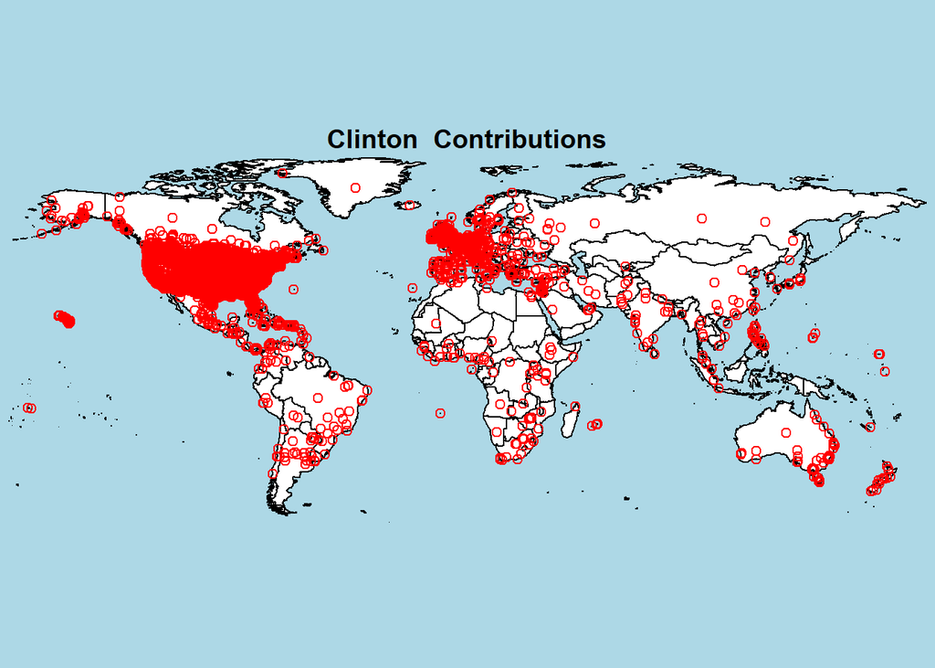

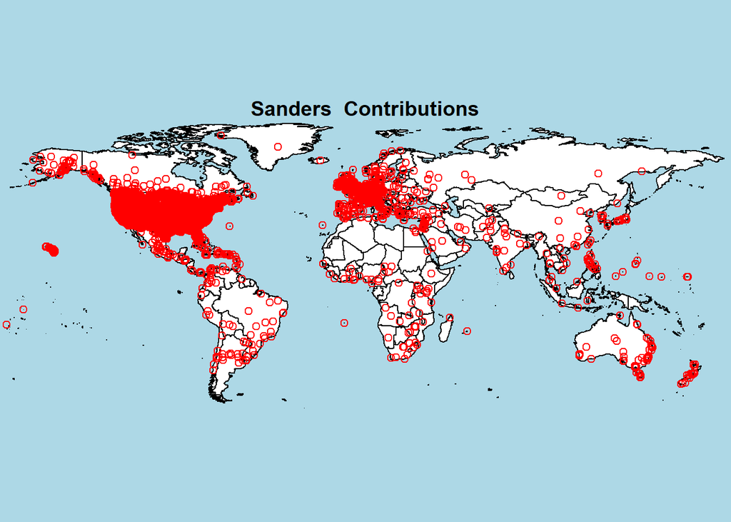

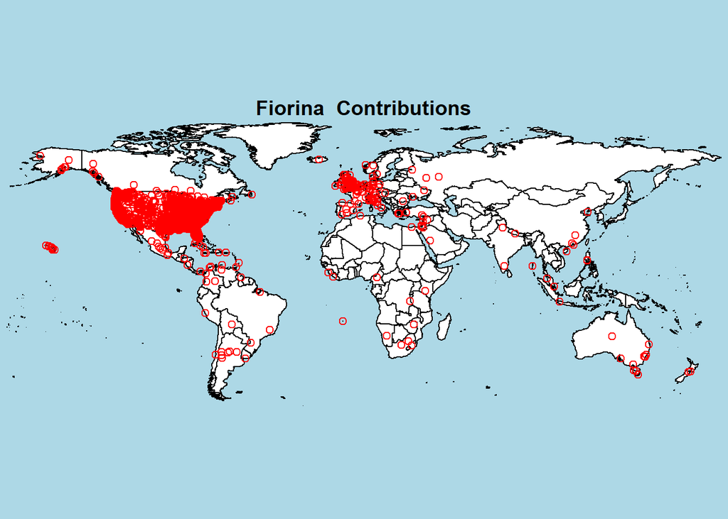

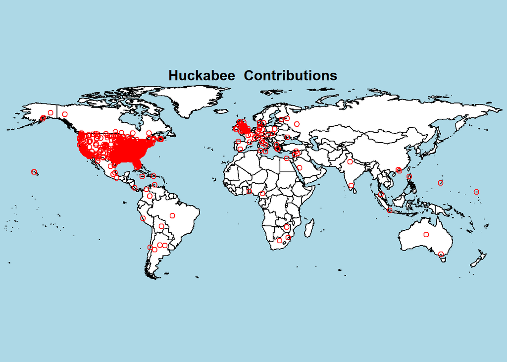

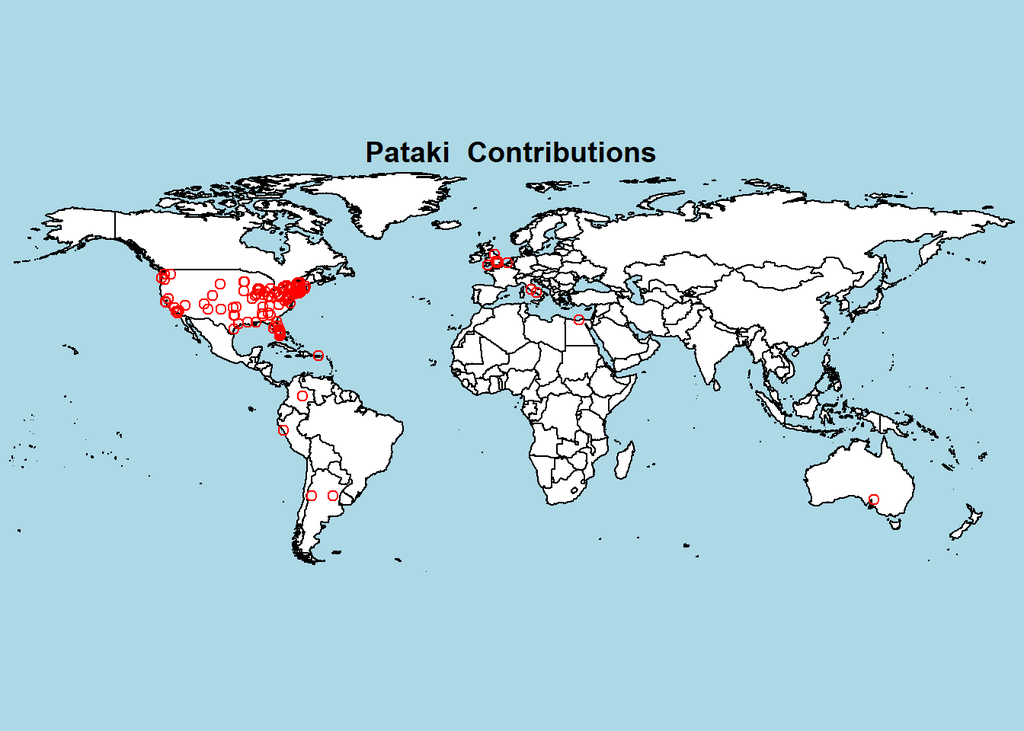

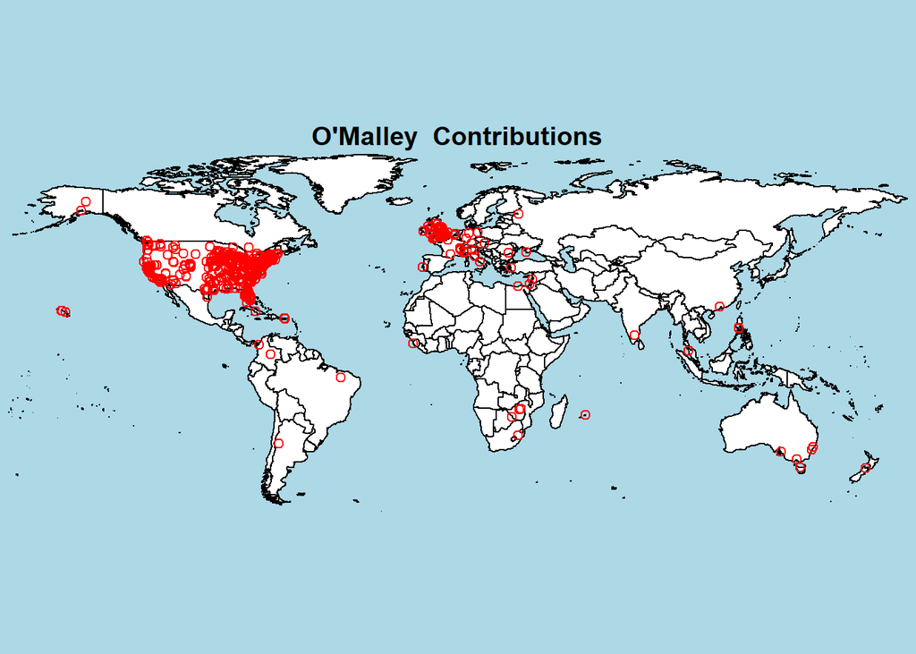

[13 more figures not shown]

```r
for (i in namelist){
  map("world", fill=TRUE, col="white", bg="lightblue", ylim=c(-60, 90),
      mar=c(0,0,0,0))
  points(x=get(i)$lon,y=get(i)$lat,col="red")
  title(main=paste(i," Contributions"))}
```

```r
#Plotting each candidate dataframe by city.
```

This visualization of contributions by city looks fine, but I believe this can be done in a somewhat more aesthetically pleasing way. In these first two attempts all candidate maps are displayed, just to allow for any viewer to be able to view the information for any candidate, as well as notice some of the striking differences such as Rubio getting quite a few donations from Europe.

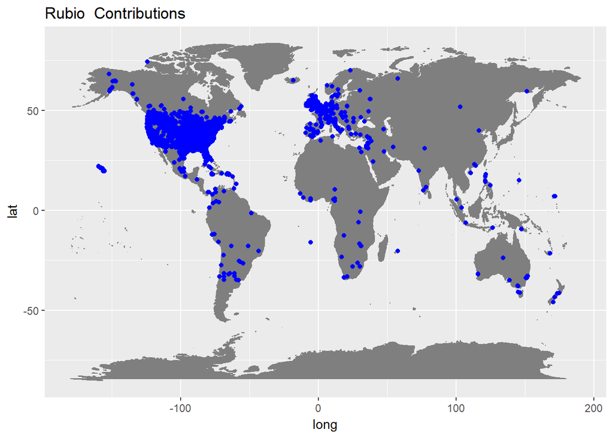

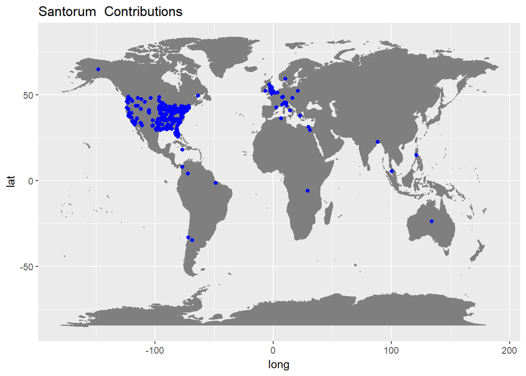

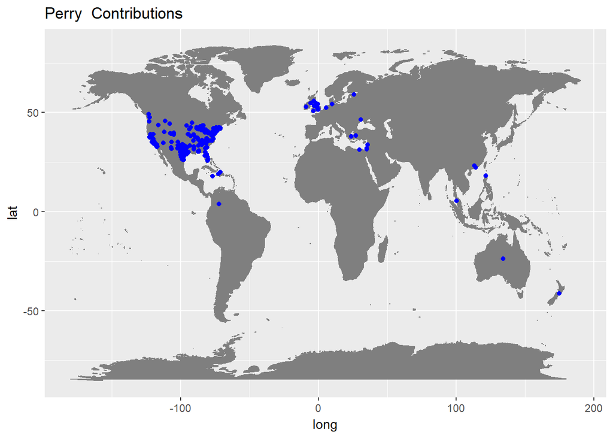

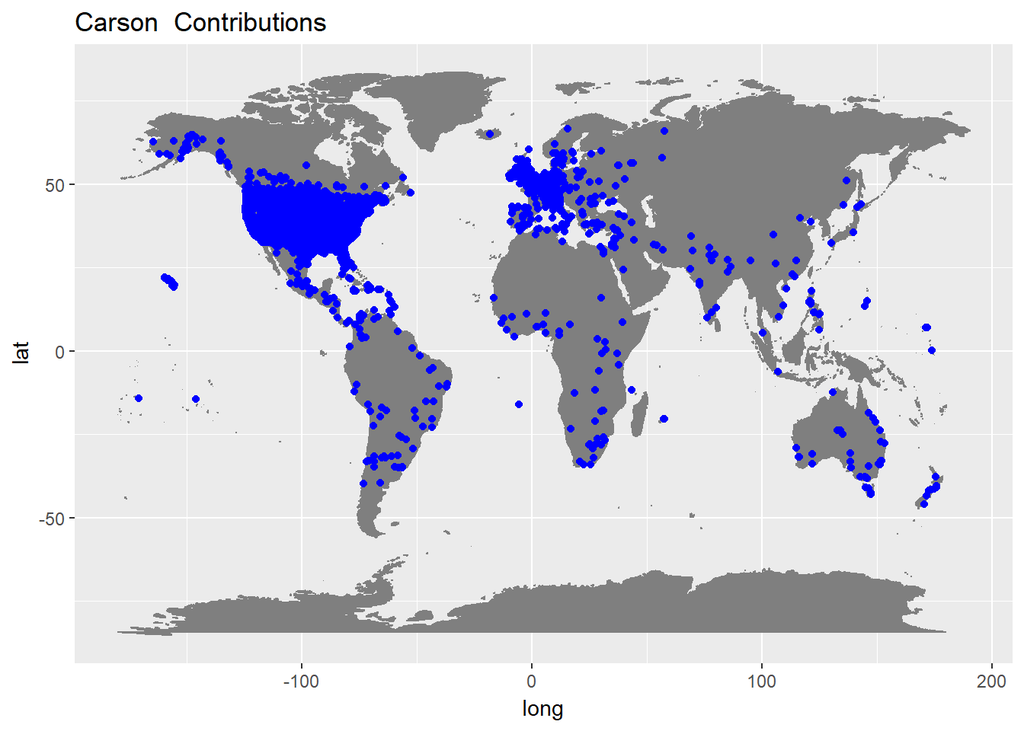

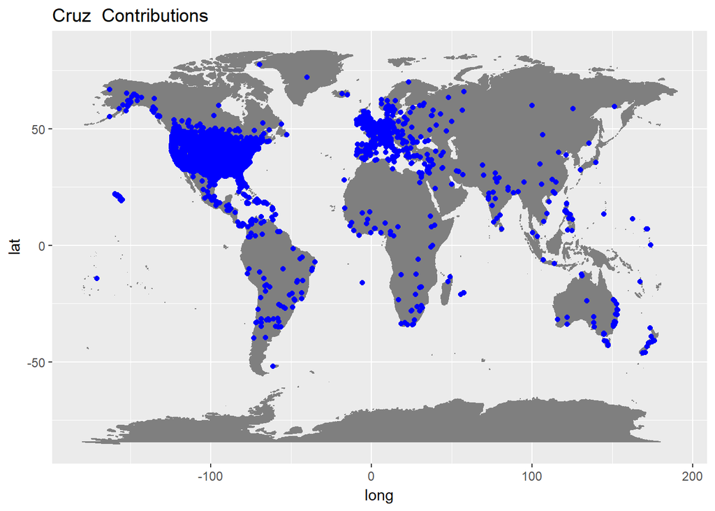

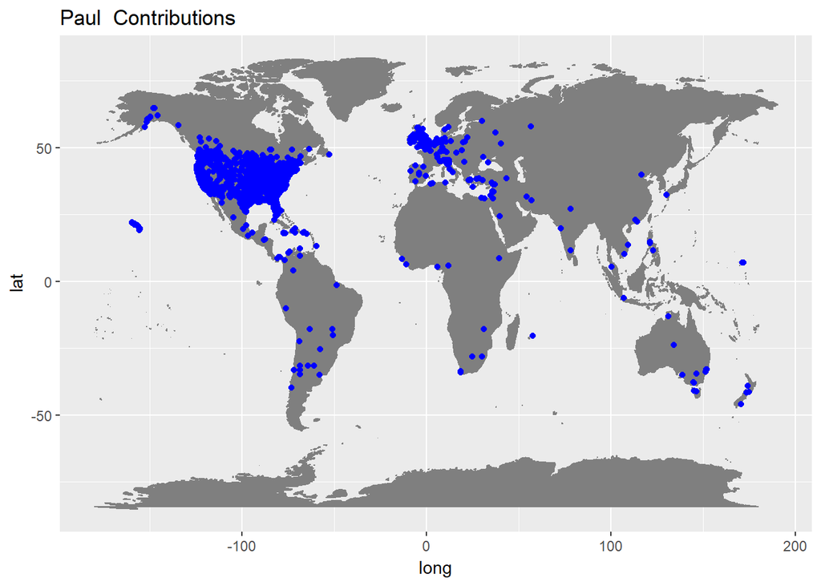

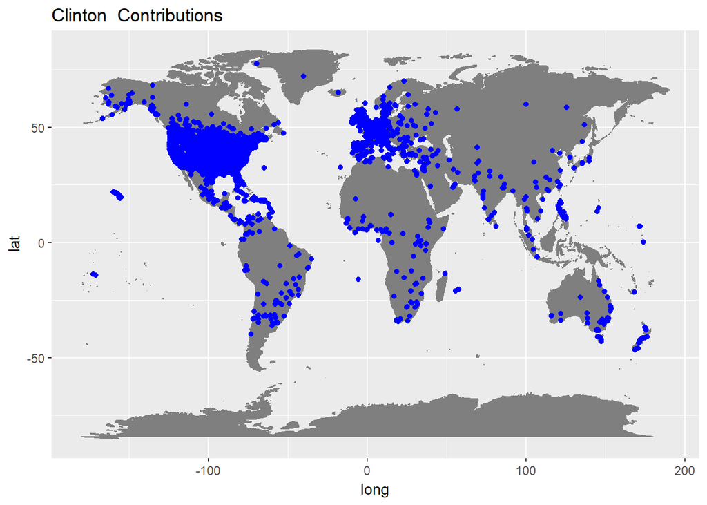

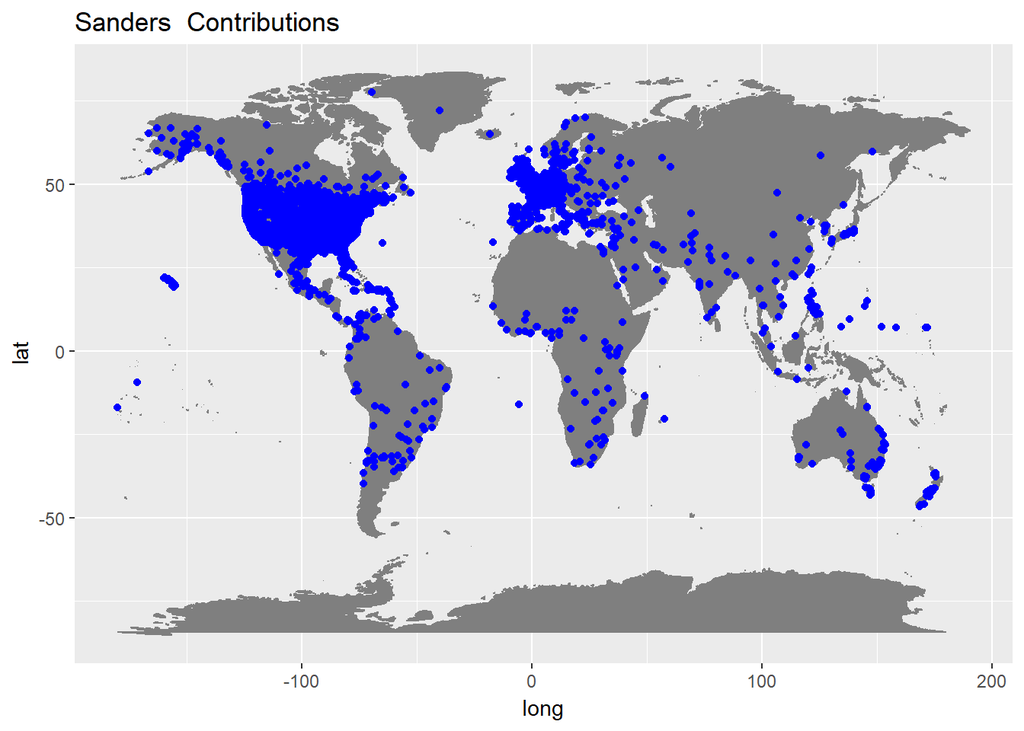

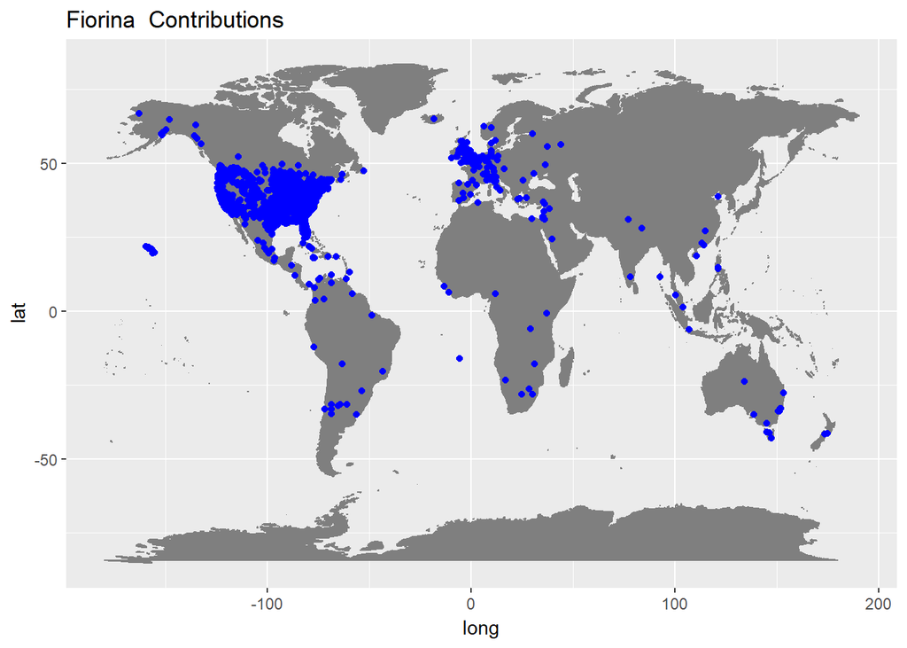

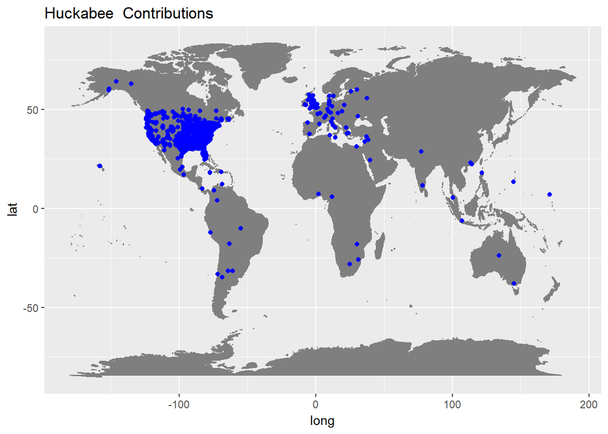

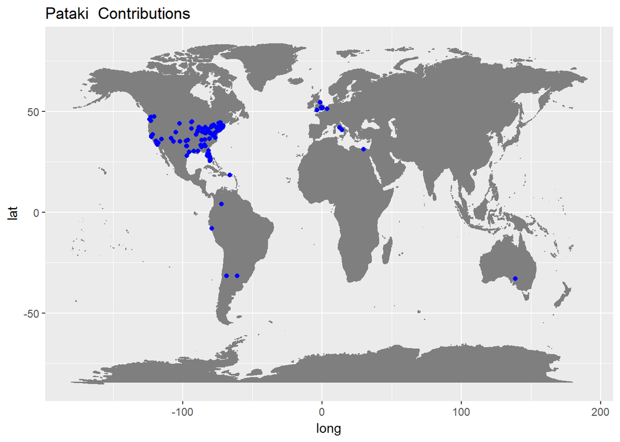

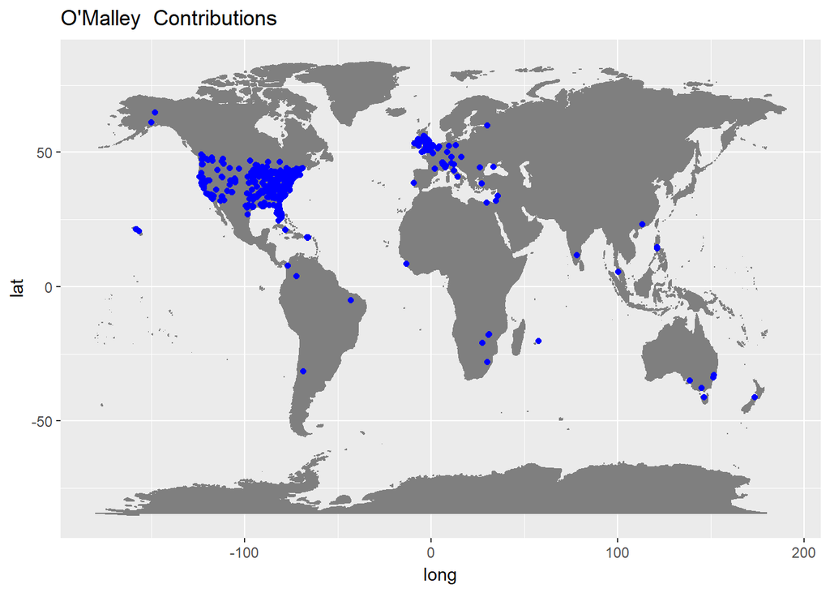

[13 more figures not shown]

```r
for (i in namelist){
  print(ggplot()+borders("world",colour="gray50",fill="gray50")+
          geom_point(data=get(i),mapping=aes(x=lon,y=lat),
                     col='blue')+
          ggtitle(paste(i," Contributions"))
        #using borders and ggplot to plot the data.
        )
}
```

This looks better but at this point, the data can definitely be fine-tuned using other variables such as the sum of contributions.

```r
for (i in namelist){
  a<-get(i)
  a$sum_of_cont<-(subset(plotCont,names==i)%>%
      group_by(names,contbr_city,contbr_st) %>% #Again grouping by city and state, but to get sum of contributions
      summarize(sum=sum(contb_receipt_amt),     #by city this time.
                n=n()) %>%
      ungroup() %>%
      ungroup())$sum
  assign(i,a)
  rm(a)
}
```

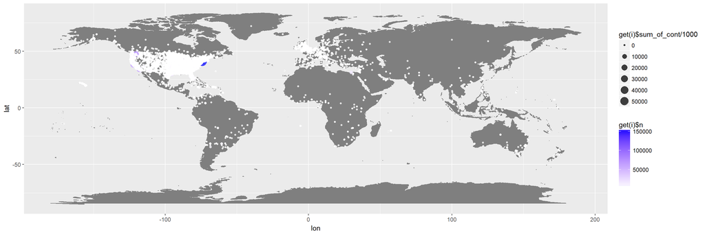

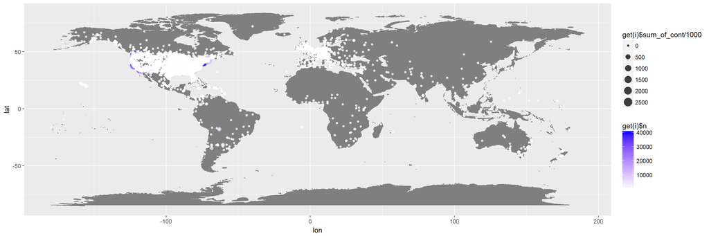

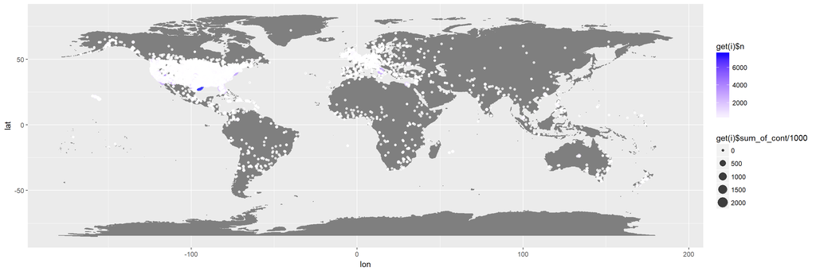

```r
for (i in c("Clinton","Sanders","Trump")){
  print(ggplot(aes(x=lon,y=lat),data=get(i))+borders("world",colour="gray50",fill="gray50")+
    geom_point(alpha=.75,aes(col=get(i)$n,size=get(i)$sum_of_cont/1000))+
      scale_color_gradient2(low = "red", mid = "white", high = "blue")) #Redoing the maps with size and color affected
}                                                                       #by sum and count.
```

These plots definitely look a lot better and contain a lot more information, and I restrict the maps to only the main candidates!